# Energy Production in the United States

T. Morrison

March 29, 2016

In this post, I am going to be doing some data visualization with data on energy production in the United States from 1990 to 2014. The data comes courtesy of the Energy Information Administration (specifically here under “Net Generation by State by Type of Producer by Energy Source”). They have a lot of interesting data available I will certainly be exploring in the future.

```r
library(readxl)
library(tidyr)
library(dplyr)
library(ggplot2)
library(data.table)
library(ggthemes)
```

For every year and every state, there is generation energy data for fourteen methods of production (coal, wind, natural gas, etc.) and six types of energy producers. Today, I wanted to look at just the total production by source, so I needed to do some data cleaning to end up with a workable data set.

First, I loaded in the .xls file using `read_excel()` from the `readxl` package, which automatically loads it as a tbl_df for use with dplyr.

```r
GenerationByState<- read_excel("C:/Users/tmo/Desktop/R/energygenerationbystate.xls", skip=1)
names(GenerationByState) <- c("Year","State","Producer","Source","Mwhs")
```

Then using `filter()`, I broke that parent data set into four smaller ones with only the “Total Electric Power Industry” producer type, according to the U.S. Census Bureau-defined regions: Midwest, Northeast, South, and West.

```r
State <- filter(GenerationByState, Producer=="Total Electric Power Industry")

Midwest <- filter(GenerationByState, State %in% c("IL","OH","WI","ND","SD","NE","KS","IA","MN","IN","MO","MI"))
Northeast <- filter(GenerationByState, State %in% c("CT","ME","MA","NH","RI","VT","NJ","NY","PA"))
West <- filter(GenerationByState, State %in% c("AZ","CO","ID","MT","NV","NM","UT","WY","AK","CA","HI","OR","WA"))
South <- filter(GenerationByState, State %in% c("AL","KY","MS","TN","AR","LA","OK","TX","DE","FL","GA","MD","NC","SC","VA","WV", "DC"))

tepiMW <- filter(Midwest, Producer=="Total Electric Power Industry")
tepiNE <- filter(Northeast, Producer=="Total Electric Power Industry")
tepiW <- filter(West, Producer=="Total Electric Power Industry")
tepiS <- filter(South, Producer=="Total Electric Power Industry")
```

These data sets are good for comparing state by state production within a region, but I wanted to have a look region by region first. In order to do that, I needed to get the sum total energy production by source for each year within the region, i.e. adding each state’s production by type and year for the entire region.

The easiest solution for me lay within the data.table package. After converting my regional data sets to data.tables, I used the powerful subsetting functionality of the package to add “Mwhs” for each source by year.

```r
function2 <- function(df) {
              x <- data.table(df)
              y<-x[,.(SourceSum=sum(Mwhs), Region=Region), by=.(Source, Year)]
              y
}

tepiMW$Region <- "MW"
tepiS$Region <- "S"
tepiNE$Region <- "NE"
tepiW$Region <- "W"

list <- list(tepiMW,tepiNE,tepiW,tepiS)
list2 <- lapply(list, function2)
```

The second line of the above function takes the existing data.table (x) and creates a new data.table with the columns SourceSum, Source, and Year. SourceSum is defined by the sum of Mwhs by Year and Source. So, for every observation with the same Year and Source, the Mwhs variable is added and creates a new observation with the same Year and Source, but now there is no State variable. I used `lapply` to perform the function on each dataset in a list. The resulting data.table (I also added a Region variable):

```r
head(list2[2])
```

```
## [[1]]
##            Source Year   SourceSum Region
##    1:       Total 1990 460518729.0     NE
##    2:       Total 1990 460518729.0     NE
##    3:       Total 1990 460518729.0     NE
##    4:       Total 1990 460518729.0     NE
##    5:       Total 1990 460518729.0     NE
##   ---
## 2116:        Wind 2014   9611100.2     NE
## 2117:        Wind 2014   9611100.2     NE
## 2118: Other Gases 2014    652458.6     NE
## 2119: Other Gases 2014    652458.6     NE
## 2120: Other Gases 2014    652458.6     NE
```

I then combined the four regional data.tables into one data.table with the unique Region variable to differentiate between the regions.

```r
TotalsRegion<-rbind(list2[[1]], list2[[2]], list2[[3]], list2[[4]])
```

By concatenating the Year variable (e.g. 1990) with “01-01” and no separator, the resulting string “1990-01-01” could be converted correctly to Date type.

Now for the plot.

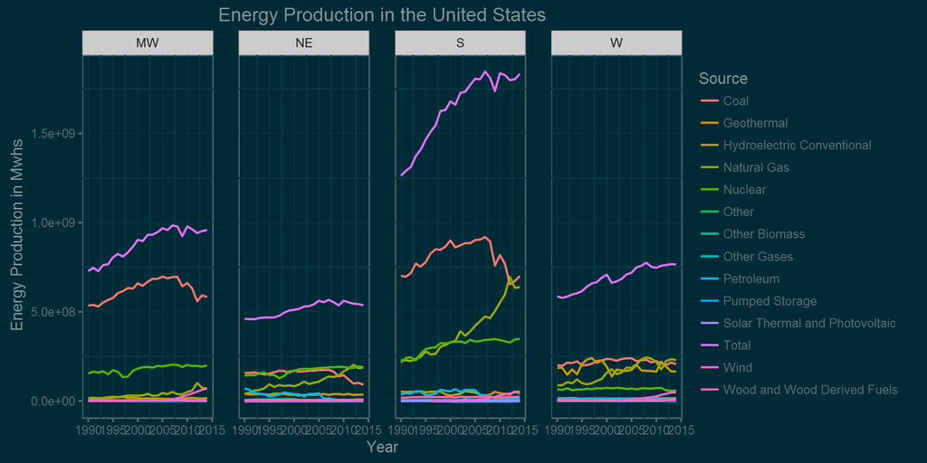

```r
ggplot(TotalsRegion, aes(x=Year, y=SourceSum, col=Source)) +
  geom_line(size=.6) +
  facet_grid(.~Region) +
  ggtitle("Energy Production in the United States") + xlab("Year") + ylab("Energy Production in Mwhs") +
  theme_solarized(light=F) + theme(panel.margin.x=unit(20,"pt"))
```

Thoughts (keeping in mind this is energy production by region, not necessarily consumption):

How about a look at just the renewable sources of energy? Note the different scale on the y-axis as well as the changes to the legend.

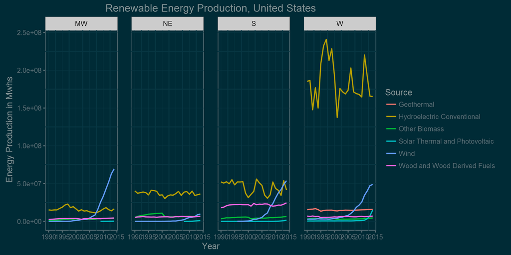

```r
renewables<-c("Hydroelectric Conventional","Geothermal","Other Biomass","Solar Thermal and Photovoltaic","Wind","Wood and Wood Derived Fuels")

ggplot(filter(TotalsRegion, Source%in%renewables), aes(x=Year, y=SourceSum, col=Source)) +
  geom_line(size=.6) +
  facet_grid(.~Region) +
  ggtitle("Renewable Energy Production, United States") + xlab("Year") + ylab("Energy Production in Mwhs") +
  theme_solarized(light=F) + theme(panel.margin.x=unit(20,"pt"))
```

Up next I’ll take a deeper look at energy production in the US and pull in some more data sets from the EIA and maybe other economic and demographic data.